# Implementation Of Persistent Binary Trie

Team Name : **TEAM ROCKET**  
Member 1 : **Neelesh Bhakt** (2018201022)  
Member 2 : **Tarpit Sahu** (2018201089)

## 1. Introduction

### 1.1. Trie Data Structure

In computer science, a trie, also called digital tree, radix tree or prefix tree is a kind of search tree—an ordered tree data structure used to store a dynamic set or associative array where the keys are usually strings. Unlike a binary search tree, no node in the tree stores the key associated with that node; instead, its position in the tree defines the key with which it is associated.

[figure not shown]

### 1.2. Binary Trie

Binary Tries are like usual tries are used to store strings containing only two characters i.e. 0 and 1. In this project we use Binary Trie to store the 32-bit binary representation of positive integers.

#### Structure to represent a Binary Trie Node

Every node of a binary trie consists of **two branches, one for 0 and other for 1**. A Trie node field **isEnd** is used to distinguish the node as end of word node. A simple structure to represent binary strings is given below:

```python
struct trie
{
    bool isEnd;
    struct trie* node[2];
};
```

#### 1.2.1. Adding an Element into a Binary Trie

Insertion in a Binary Trie is fairly simple and straight forward. Every character of the binary string is inserted in the Trie as an **individual Trie Node**.

The **node** (an array of pointers) points to the next level trie nodes. The character '0' or '1' acts as an index into the node array. If the input key is new or an extension of existing key, we need to construct non-existing nodes of the key, and mark end of word for last node. If the input key is prefix of existing key in Trie, we simply mark the last node of key as end of word. The key length determines Trie depth.

PSEUDOCODE **trie_insert(trie,string)**

> 1. Find the place of the item by following bits
> 2. If there is nothing, just insert the item there as a leaf node
> 3. If there is something on the leaf node, it becomes a new in inner node depending how the item to be inserted and the item that was in the leaf node differs.
> 4. Create new leaf nodes where you store the item that was to be inserted and the item that was originally in the leaf node.

#### 1.2.2. Searching an Element in a Binary Trie

Searching for a key is similar to insert operation, however we only compare the characters and move down. The search can terminate due to end of string or lack of key in trie. In the former case, if the **isEnd** field of last node is true, then the key exists in trie. In the second case, the search terminates without examining all the characters of key, since the key is not present in trie. The code below illustrates the search procedure in a binary trie.

PSEUDOCODE **trie_search(trie,string)**

> 1.For each character in the string, see if there is a child node with that character as the content.  
> 2.If that character does not exist, return false.  
> 3.If that character exist, repeat step 1.  
> 4.Do the above steps until the end of string is reached.  
> 5.When end of string is reached and if the marker (NotLeaf) of the current Node is set to false,  
> return true,  
> else  
> return false.

### 1.3. Persistent Data Structure

A persistent data structure is a data structure that always preserves the previous version of itself when it is modified. They can be considered as ‘immutable’ as updates are not in-place.

There are several classes of Persistance which are explained below :

- **Partial Persistence**

  > In this persistence model we may **query any previous version** of the data structure, but we may **only update the latest** version. We have operations read(var, version) and newversion = write(var, val). This definition implies a linear ordering on the versions like patial persistence in version diagrams.
- **Full Persistence**

  > In this model, **both updates and queries are allowed on any version** of the data structure. We have operations read(var, version) and newversion = write(var, version, val). The versions form a branching tree as in full persistence in version diagrams.
- **Confluent Persistence**

  > In this model, **in addition to the previous operation, we allow combination operations to combine input of more than one previous versions to output a new single version**. We have operations read(var, version), newversion = write(var, version, val) and newversion = combine(var, val, version1, version2). Rather than a branching tree, combinations of versions induce a DAG (direct acyclic graph) structure on the version graph, shown in confluent persistence in version diagrams.
- **Functional Persistence**

The difference between functional persistence and the rest is we have to keep all the structures related to previous versions intact: the only allowed internal operation is to add new nodes. In the previous three cases we were allowed anything as long as we were able to implement the interface.

**Version Diagrams** Following diagrams represent above classes of persistence. Grey node indicates read-only version and Blue node indicates read-write version.

[figure not shown]

#### 1.3.1. Examples of Persistent Data Structure

Following are some of the examples of persistent datastructure/operations.

- **Linked List Concatenation**  
  Consider the problem of concatenating two singly linked lists with n and m as the number of nodes in them. Say $n>m$ . We need to keep the versions, i.e., we should be able to original list. One way is to make a copy of every node and do the connections. $O(n + m)$ for traversal of lists and $O(1)$ each for adding $(n + m – 1)$ connections. Other way, and a more efficient way in time and space, involves traversal of only one of the two lists and fewer new connections. Since we assume $m<n$, we can pick list with $m$ nodes to be copied. This means $O(m)$ for traversal and $O(1)$ for each one of the $m$ connections. We must copy it otherwise the original form of list wouldn’t have persisted.

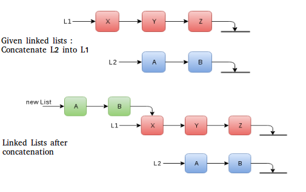

- **Binary Search Tree Insertion**  
  Consider the problem of insertion of a new node in a binary search tree. Being a binary search tree, there is a specific location where the new node will be placed. All the nodes in the path from the new node to the root of the BST will observe a change in structure (cascading). For example, the node for which the new node is the child will now have a new pointer. This change in structure induces change in the complete path up to the root.

This example is taken from Okasaki.  
$xs = [a, b, c, d, f, g, h]$

might be represented by the following binary search tree:

[figure not shown]

#### 1.3.2. Techniques to implement Persitent Datastructures

For the methods suggested below, updates and access time and space of versions vary with whether we are implementing full or partial persistence.

- **Path copying:**  
  Make a copy of the node we are about to update. Then proceed for update. And finally, cascade the change back through the data structure, something very similar to what we did in example two above. This causes a chain of updates, until you reach a node no other node points to — the root. How to access the state at time t? Maintain an array of roots indexed by timestamp.
- **Fat nodes:**  
  As the name suggests, we make every node store its modification history, thereby making it ‘fat’.
- **Nodes with boxes:**  
  Amortized $O(1)$ time and space can be achieved for access and updates. This method was given by Sleator, Tarjan and their team. For a tree, it involves using a modification box that can hold:
  - one modification to the node (the modification could be of one of the pointers, or to the node’s key or to some other node-specific data)
  - the time when the mod was applied

## 2. Persistent Binary Trie

We implemented partial persistent Binary Trie that stores binary strings formed by 0s and 1s. By partial persistent we mean that insertion is only allowed in the latest version whereas we can query any previous version. In other words, the first version of trie contains only 1 key, second version contains first two keys, third version contains first three keys and so on.

[figure not shown]

# Space Complexity Analysis : Comparison with Non-Persistent Version

[figure not shown]

First, consider the case of **Persistent Binary Trie** . Suppose we have $n$ binary strings of $32$ bits each. In our implementation we create a new version with every insertion of a string. For $k$ bit string we require $k+1$ nodes.  
Similarly, for $n$ strings of $32$ bits we require $O(n*(32+1))$ space i.e. $O(n)$ space.

[figure not shown]

Now coming to **Non Persistent Binary Trie** , for $n$ binary strings of $32$ bits each, we will create a different trie each time inserting all previous values.  
For calculating space complexity, let us consider the upper bound of space required in each version. Therefore we require,  
$(32+1) + 2*(32+1) + 3*(32+1) + ... + n*(32+1) = O(n^2*(32+1))$ space i.e. $O(n^2)$ space.

| Trie | Space |
| --- | --- |
| Persistent | $O(bits * n)$ |
| Non-Persistent | $O(bits * n^2)$ |

Table showing the space complexity of Persistent and Non Persistent Trie to store n binary strings.

[figure not shown]

Graph showing space required by Persistent and Non Persistent Trie to store n binary strings.

### 2.1 Applications of Persistent Binary Trie

We analysed various problems that could be solved using concept of persistent data structure in an efficient manner. We present two problems, their solution and comparison with other approaches.

2.1.1 maxXOR in a given range We are given following variables :

> $n$= number of elements  
> $a_i$= array element (non-negative integer) $l$= left most index of range  
> $r$= right most index of range  
> $q$= number of queries  
> $k_i$= a number

The task is to find an element that would give maximum XOR for each of q queries $k_i$. Assume the integers are only of 32 bits and value of q can be very large. Devise an efficient datastructure/algorithm.

**Approach 1: Brute Force**

For each query $k_i$ loop from $l$ to $r$ and compute XOR with each element and store the one that yields maximum XOR.

Time Complexity : $O(q*(r-l))$  
In worst case $l=1$ and $r=n$, the time complexity becomes $O(q*n)$

**Since the value of q can be very large, we need to think of an improved algorithm.**

**Approach 2: Persistent Binary Trie**

For each element in the array, insert the element every time in a new version, thereby creating a Persistent Trie. Now we can query the trie to find required element.

Time Complexity :  
$O((32+1)*n)$i.e. $O(n)$ for Persistent Trie creation. (only once)  
$O(32)$ i.e. $O(1)$ for each query  
Therefore, total time required : $O(n+q*1)$ i.e. $O(n+q)$

**Now we can answer each query in constant time, hence time complexity is improved from $O(nq)$ to $O(n+q)$.**

| Approach | Time Complexity | Space Complexity |
| --- | --- | --- |
| Brute Force | $O(n*q)$ | O(1) |
| Persistent Trie | $O(n+q)$ | O(n) |

Comparison Table : Comparing Approach 1 and 2

#### 2.1.2 Finding k$^{th}$ minimum in a range $l$ to $r$ (both inclusive) of an array.

The task is to find $k^{th}$ minimum element in a range $l$ to $r$ an array of $n$ elements. Assume the integers to be non-negative and 32 bits length.

**Approach 1: Brute Force**

Loop between $l^{th}$ and $r^{th}$ index and find $k^{th}$ minimum using repeated looping. Time Complexity : $O(k*(r-l))$  
In worst case $l=1$, $r=n$ and $k$= $\dfrac{n}{2}$. If $k$ > $\dfrac{n}{2}$, we can use $(n-k)^{th}$ max strategy, the time complexity becomes $O(\dfrac{n}{2}*n) = O(n^2)$

**Approach 2: Sorting**

Sort the array between $l^{th}$ and $r^{th}$ index and find $k^{th}$ minimum.  
Time Complexity : $O((r-l)*log(r-l))$  
In worst case $l=1$, $r=n$, the time complexity becomes $O(n*log n)$

**Approach 3: Persistent Binary Trie**

For each element in the array, insert the element every time in a new version, thereby creating a Persistent Trie ($i^{th}$ version contains key entered from $0$ to $i$). Store count on each node that represents number of paths from that node.

Traverse the $R^{th}$ trie and $(L-1)^{th}$ trie parallely, subtracting the count of $(L-1)^{th}$ trie's node from count of $R^{th}$ trie's node, which will basically include the count of numbers present only in $L$ to $R$.

Now, the procedure to find $k^{th}$ minimum is similar to that of AVL trees. Check the number of elements on left side of a node, if it is less than or equal to k then go towards left else go towards right after subtracting k by the count on left.

Time Complexity :  
$O((32+1)*n)$i.e. $O(n)$ for Persistent Trie creation. (only once)  
$O(32)$ i.e. $O(1)$ for changing counts of $R^{th}$ trie  
$O(32)$ i.e. $O(1)$ for finding the $k^{th}$ min.  
Therefore, total time required : $O(n+1+1)$ i.e. $O(n)$.

| Approach | Time Complexity | Space Complexity |
| --- | --- | --- |
| Brute Force | $O(n^2)$ | O(1) |
| Sorting | $O(n*log n)$ | O(1) |
| Persistent Trie | $O(n)$ | O(n) |

Comparison Table : Comparing Approaches 1,2 and 3.

[figure not shown]

Graph showing Time Complexity of different approaches to solve Application 2  
Persistent Trie, Brute Force and Sorting

## 3. Code

The project is done in C++ language. Complete source code of this project can be downloaded from the following repository :  
http://10.3.1.184/tarpitsahu/persistent-trie

## 4. References

- Making data structures persistent, James R.Driscoll et al, Journal of Computer and System Sciences, Volume 38, Issue 1, February 1989, Pages 86-124.
- https://ocw.mit.edu/courses/electrical-engineering-and-computer-science/6-854j-advanced-algorithms-fall-2005/lecture-notes/persistent.pdf
- https://en.wikipedia.org/wiki/Persistent_data_structure
- Persistent Data Structures (Video Lecture by Eric Demaine) : https://www.youtube.com/watch?v=T0yzrZL1py0
- https://www.codeproject.com/Articles/9680/Persistent-Data-Structures
- http://tildeweb.au.dk/au121/aa11/slides/persistent.pdf
- http://olympiad.cs.uct.ac.za/presentations/camp3_2017/persistentdatastructures.pdf